# Project- DuPont Analysis: III - Apply appropriate data analytic techniques

FIRE 540: Financial Analytics

Author

Affiliation

Larry Tentor

Virginia Commonwealth University

# Student Name

ROHITH RAVINDRA REDDY

## Academic Integrity Statement

*I, Rohith Ravindra Reddy , hereby state that I have not communicated with or gained information in any way from my classmates or anyone other than the Professor or TA during this project, and that all work is my own.*

## Grading and feedback

The total points for the questions add up to 64 points (each problem is graded on a 4 point scale A (4) - b (3) - C (2) - F (1) - not attempted (0)). The remaining 8 points are allocated to code style, messages, overall organization, spelling, grammar, etc.

## Project Guidlines

1. **No Public Questions.** You are not allowed to post any questions on a public or private internet community (like StackOverflow). Any questions about the project must be asked in e-mails to faculty.
2. **Citation Necessary, Avoid Plagerism.** I am well aware that a huge volume of code is available on the web to solve any number of problems. For this project you are allowed to make use of any online resources (e.g. R for Data Science book, StackOverflow) but you must explicitly cite where you obtained any code you directly use (or use as inspiration). You are also not allowed to ask a question on a forum, you may only use answers to questions that have already been answered. Any recycled code that is discovered and is not explicitly cited will be treated as plagiarism. All communication with classmates is explicitly forbidden.
3. **TidyVerse R Preferred.** Please use R and the modern tidyverse functions to solve the below challenges.
4. **Analysis Responses Necessary.** Please replace the **STUDENT RESPONSE REQUIRED** with complete sentences answers. All submitted work shall represent the student’s own thoughts and typing. Students may be asked to explain their answer. Each question may have a brief narrative or description of your approach. You can use comments in your code, but do not extensively count on these. Even if the answer seems obvious from the R output, make sure to state it in your analysis as well.
5. **Quarto Document, with HTML Submission.** Your solutions must be written up in the Quarto Markdown (qmd) file. This file must include your code and any text answers for each task. Your “submission” will be the rendered HTML output that you submit to Canvas. I should be able to suppress **all** the code in your document and still be able to read and make sense of your answers. See the first setup code chunk in your qmd file to experiment with suppressing and revealing your code.
6. **Instructor or TA to Answer Questions.** You **may not** consult with anyone else about this project other than the Professor or TA for this course. You cannot ask direct questions on the internet, or consult with each other, not even for hypothetical questions.
7. **Dates on Learning Management System.** The project due date is established via Canvas.

## Part III: DuPont Analysis: Apply appropriate data analytic techniques

## Background

The data for this case was extracted from company financial statements posted online from credible sources. Many of the transformations has been done for you as well. Balance sheet data and income statement data were in separate files and have been matched by company and year into a single file. The resulting file is a comma separated values (csv) file, `dupont-analysis-combined.csv`, that is ready to be loaded into R. You will be need to compute the ratios involved in the DuPont Method once it has been loaded into R.

**The student is required to check data to make certain values are within expected ranges and are valid.**

## Financial Statment Import

**Import Settings**

```r
# Assignment comes with extract handled to allow student to focus
# on transformation, profile and analysis.
nameColumns <- c( 'Ticker'
                , 'Name'
                , 'Industry'
                , 'Year'
                , 'FinancialStatement'
                , 'Cash'
                , 'InvestmentShortTerm'
                , 'CashAndShortTerm'
                , 'AccountsReceivables'
                , 'Inventories'
                , 'OtherCurrentAssets'
                , 'TotalCurrentAssets'
                , "GrossPropertyPlantandEquipment"
                , 'TotalDepreciation'
                , 'IntangibleAssets'
                , 'TotalOtherAssets'
                , 'TotalAssets'
                , 'AccountsPayable'
                , 'ShortTermDebt'
                , 'AccruedExpenses_Liability'
                , 'OtherCurrentLiabilities'
                , 'OtherLiabilities'
                , 'LongTermDebt'
                , 'DeferredTaxes_Liability'
                , 'OtherLiabilities1'
                , 'TotalLiabilities'
                , 'MinorityInterest_Equity'
                , 'PreferredStock_Equity'
                , 'CommonEquity'
                , 'ShareholderEquity'
                , 'CommonSharesOutstanding'
                , 'PrepaidExpenses'
                , 'CashDueFromBanks_Asset'
                , 'Ticker_IncomeStatement'
                , 'Year_IncomeStatement'
                , 'FinancialStatement_IncomeStatement'
                , 'NetRevenues'
                , 'CostofGoodsSold'
                , 'DepreciationAndAmortizationExpense'
                , 'GrossIncome'
                , 'GeneralExpenses'
                , 'ResearchAndDevelopmentExpense'
                , 'TotalOperatingExpenses'
                , 'OperatingIncome'
                , 'ExtraordinaryCredit'
                , 'ExtraordinaryCharge'
                , 'InterestExpenseOnDebt'
                , 'OtherNonOperatingExpenses'
                , 'PreTaxIncome'
                , 'IncomeTaxExpense'
                , 'NetIncome'
                , 'SharesToCalculateEPS'
                , 'SharesToCalculateEPSDiluted'
                , 'EarningsPerShare'
                , 'DilutedEarningsPerShare'
                , 'DiscontinuedOperations'
                , 'ExtraordinaryItems'
                , 'MinorityInterest'
                , 'PreTaxEquityEarnings'
                , 'EquityInEarnings'
                , 'OtherOperatingExpenses'
                , 'PreferredDividend'
                , 'OtherOperatingIncome'
                , 'LoanLossProvision'
                , 'InterestExpenseTotal'
                , 'InterestIncome'
                , 'NonInterestIncomeTotal'
                , 'NonInterestExpense'
                , 'UnderwritingExpenses'
                , 'PremiumsEarned'
                , 'ClaimAndLoss'
                , 'AssetTurnoverforIndustry'
                , 'NetIncomeforIndustry'
                , 'EquityforIndustry'
                , 'SalesforIndustry'
                , 'AssetsforIndustry'
                , 'PositiveNetIncome'
                , 'ROEforIndustry'
                , 'ROE'
                , 'ProfitMargin'
                , 'AssetTurnover'
                , 'FinancialLeverage'
                , 'FinancialLeverageforIndustry'
                , 'ProfitMarginforIndustry'
                )
typeColumns <- cols(
  Ticker                                        = col_character(),
  Name                                          = col_character(),
  Industry                                      = col_factor(NULL), # col_character(),
  Year                                          = col_integer(),    # col_double(),
  FinancialStatement                            = col_factor(NULL), # col_character(),
  Cash                                          = col_double(),
  InvestmentShortTerm                           = col_double(),
  CashAndShortTerm                              = col_double(),
  AccountsReceivables                           = col_double(),
  Inventories                                   = col_double(),
  OtherCurrentAssets                            = col_double(),
  TotalCurrentAssets                            = col_double(),
  GrossPropertyPlantandEquipment                = col_double(),
  TotalDepreciation                             = col_double(),
  IntangibleAssets                              = col_double(),
  TotalOtherAssets                              = col_double(),
  TotalAssets                                   = col_double(), # DuPont
  AccountsPayable                               = col_double(),
  ShortTermDebt                                 = col_double(),
  AccruedExpenses_Liability                     = col_double(),
  OtherCurrentLiabilities                       = col_double(),
  OtherLiabilities                              = col_double(),
  LongTermDebt                                  = col_double(),
  DeferredTaxes_Liability                       = col_double(),
  OtherLiabilities1                             = col_double(),
  TotalLiabilities                              = col_double(),
  MinorityInterest_Equity                       = col_double(),
  PreferredStock_Equity                         = col_double(),
  CommonEquity                                  = col_double(),
  ShareholderEquity                             = col_double(), # DuPont
  CommonSharesOutstanding                       = col_double(),
  PrepaidExpenses                               = col_double(),
  CashDueFromBanks_Asset                        = col_double(),
  Ticker_IncomeStatement                        = col_character(),
  Year_IncomeStatement                          = col_integer(), # col_double(),
  FinancialStatement_IncomeStatement            = col_factor(NULL), # col_character(),
  NetRevenues                                   = col_double(), # DuPont
  CostofGoodsSold                               = col_double(),
  DepreciationAndAmortizationExpense            = col_double(),
  GrossIncome                                   = col_double(),
  GeneralExpenses                               = col_double(),
  ResearchAndDevelopmentExpense                 = col_double(),
  TotalOperatingExpenses                        = col_double(),
  OperatingIncome                               = col_double(),
  ExtraordinaryCredit                           = col_character(),
  ExtraordinaryCharge                           = col_character(),
  InterestExpenseOnDebt                         = col_double(),
  OtherNonOperatingExpenses                     = col_double(),
  PreTaxIncome                                  = col_double(),
  IncomeTaxExpense                              = col_double(),
  NetIncome                                     = col_double(), # DuPont
  SharesToCalculateEPS                          = col_double(),
  SharesToCalculateEPSDiluted                   = col_double(),
  EarningsPerShare                              = col_double(),
  DilutedEarningsPerShare                       = col_double(),
  DiscontinuedOperations                        = col_double(),
  ExtraordinaryItems                            = col_double(),
  MinorityInterest                              = col_double(),
  PreTaxEquityEarnings                          = col_double(),
  EquityInEarnings                              = col_double(),
  OtherOperatingExpenses                        = col_double(),
  PreferredDividend                             = col_double(),
  OtherOperatingIncome                          = col_double(),
  LoanLossProvision                             = col_double(),
  InterestExpenseTotal                          = col_double(),
  InterestIncome                                = col_double(),
  NonInterestIncomeTotal                        = col_double(),
  NonInterestExpense                            = col_double(),
  UnderwritingExpenses                          = col_double(),
  PremiumsEarned                                = col_double(),
  ClaimAndLoss                                  = col_double(),
  AssetTurnoverforIndustry                      = col_double(),
  NetIncomeforIndustry                          = col_double(),
  EquityforIndustry                             = col_double(),
  SalesforIndustry                              = col_double(),
  AssetsforIndustry                             = col_double(),
  PositiveNetIncome                             = col_double(),
  ROEforIndustry                                = col_double(),
  ROE                                           = col_double(), # DuPont
  ProfitMargin                                  = col_double(), # DuPont
  AssetTurnover                                 = col_double(), # DuPont
  FinancialLeverage                             = col_double(), # DuPont
  FinancialLeverageforIndustry                  = col_double(),
  ProfitMarginforIndustry                       = col_double()
  )

fileName        <- paste0(here(), '/course-material/_data/dupont-analysis-combined.csv')
```

**Access dataset `Dupont Analysis`**

```r
duPont <- read_csv( file      = fileName
                  , skip = 1
                  , col_names = nameColumns
                  , col_types = typeColumns
              #    , na        = c('', 'NA', '--')
                  )
```

## CRISP: Understand Data

You are now ready to review the data. Previously, you identified five questions that you thought would provide relevant insights of the data. Before answering those questions, answer the preliminary data questions that are listed below.

For each question:

- Identify the type of the analysis to perform
- Identify which data elements are needed to perform the analysis
- Create the analysis using R
- Answer the analysis question in sentence form.

## Data Understanding & Cleaning

A. While the instructor is responsible for properly loading the data from the file; you as the analyst are responsible for the data understanding (CRISP-DM-I) and business understanding (CRISP-DM-II). **Review the four primary ratios that we will be examining for the DuPont Analysis.**

- Some questions you should consider are: is the value of the expected data type (Integer, Decimal/Float, Categorical)?
- Can you recalculate this number and cross check it is given to you properly?
- Is the numeric sign (+/-) as you expect?
- For ratios, should the value be inverted (1/x)?

In the end, calculate the correct ratios based on the financial statement data and store with an appended `_calc`. (`ROE_calc`, `ProfitMargin_calc`, `AssetTurnover_calc`, `FinancialLeverage_calc`, and any additional data you deem necessary). Make certain that no infinite values sneak in as these will cause calculation problems for mean and standard deviation.

**Question A, Student**

```r
# Answer this sections question in well formed code.
#################################################################
# Student R code answer below
#################################################################
library(dplyr)
library(tidyr)
library(purrr)
library(stringr)
library(gt)

# ---- helper: safe divide (prevents Inf/-Inf/NaN) ---------------
safe_div <- function(n, d) {
  out <- ifelse(is.na(n) | is.na(d) | d == 0, NA_real_, n / d)
  out[is.infinite(out) | is.nan(out)] <- NA_real_
  out
}

# ---- quick data-type check (expected: numerics) ----------------
type_check <- tibble::tibble(
  Variable = c("NetIncome","NetRevenues","TotalAssets","ShareholderEquity",
               "ProfitMargin","AssetTurnover","FinancialLeverage","ROE"),
  Class = c(class(duPont$NetIncome)[1],
            class(duPont$NetRevenues)[1],
            class(duPont$TotalAssets)[1],
            class(duPont$ShareholderEquity)[1],
            class(duPont$ProfitMargin)[1],
            class(duPont$AssetTurnover)[1],
            class(duPont$FinancialLeverage)[1],
            class(duPont$ROE)[1])
) %>%
  gt() %>%
  tab_header(title = md("**Input Columns: Type Check**")) %>%
  cols_label(Variable = "Variable", Class = "R Class")

type_check
```

**Input Columns: Type Check**

| Variable | R Class |
| --- | --- |
| NetIncome | numeric |
| NetRevenues | numeric |
| TotalAssets | numeric |
| ShareholderEquity | numeric |
| ProfitMargin | numeric |
| AssetTurnover | numeric |
| FinancialLeverage | numeric |
| ROE | numeric |

**Question A, Student**

```r
# ---- compute DuPont ratios (_calc) from statements -------------
# Convention:
#   ProfitMargin_calc        = (NetIncome / NetRevenues) * 100   [%]
#   AssetTurnover_calc       =  NetRevenues / TotalAssets        [ratio]
#   FinancialLeverage_calc   =  TotalAssets / ShareholderEquity  [ratio]
#   ROE_calc                 =  PM * AT * FL  (as %)             [%]
duPont <- duPont %>%
  mutate(
    ProfitMargin_calc        = safe_div(NetIncome, NetRevenues) * 100,
    AssetTurnover_calc       = safe_div(NetRevenues, TotalAssets),
    FinancialLeverage_calc   = safe_div(TotalAssets, ShareholderEquity),
    ROE_calc                 = (ProfitMargin_calc/100) * AssetTurnover_calc * FinancialLeverage_calc * 100
  ) %>%
  mutate(across(c(ProfitMargin_calc, AssetTurnover_calc, FinancialLeverage_calc, ROE_calc),
                ~{x <- .x; x[is.infinite(x) | is.nan(x)] <- NA_real_; x}))

# ---- sanity checks on sign/magnitude ---------------------------
sanity_tbl <- tibble::tibble(
  Metric = c("Rows",
             "ROE > 1000% (count)",
             "Profit Margin outside [-100,100]% (count)",
             "Financial Leverage < 1 (count)",
             "Asset Turnover < 0 (count)",
             "Negative PM but Positive ROE (count)"),
  Value = c(
    nrow(duPont),
    sum(!is.na(duPont$ROE_calc) & duPont$ROE_calc > 1000),
    sum(!is.na(duPont$ProfitMargin_calc) & (duPont$ProfitMargin_calc < -100 | duPont$ProfitMargin_calc > 100)),
    sum(!is.na(duPont$FinancialLeverage_calc) & duPont$FinancialLeverage_calc < 1),
    sum(!is.na(duPont$AssetTurnover_calc) & duPont$AssetTurnover_calc < 0),
    sum(!is.na(duPont$ProfitMargin_calc) & duPont$ProfitMargin_calc < 0 &
          !is.na(duPont$ROE_calc) & duPont$ROE_calc > 0)
  )
) %>%
  gt() %>%
  tab_header(title = md("**Sanity Summary (Calculated Ratios)**")) %>%
  fmt_number(columns = "Value", decimals = 0)

sanity_tbl
```

**Sanity Summary (Calculated Ratios)**

| Metric | Value |
| --- | --- |
| Rows | 516 |
| ROE > 1000% (count) | 3 |
| Profit Margin outside [-100,100]% (count) | 33 |
| Financial Leverage < 1 (count) | 29 |
| Asset Turnover < 0 (count) | 0 |
| Negative PM but Positive ROE (count) | 19 |

**Question A, Student**

```r
# ---- cross-check vs provided ratio columns ---------------------
diffs <- duPont %>%
  transmute(
    ROE_diff  = if ("ROE"               %in% names(.)) ROE_calc - ROE else NA_real_,
    PM_diff   = if ("ProfitMargin"      %in% names(.)) ProfitMargin_calc - ProfitMargin else NA_real_,
    AT_diff   = if ("AssetTurnover"     %in% names(.)) AssetTurnover_calc - AssetTurnover else NA_real_,
    FL_diff   = if ("FinancialLeverage" %in% names(.)) FinancialLeverage_calc - FinancialLeverage else NA_real_
  )

diff_summary <- tibble::tibble(
  Metric = c("ROE (pp)","Profit Margin (pp)","Asset Turnover (ratio)","Financial Leverage (ratio)"),
  `Mean |Δ|` = c(mean(abs(diffs$ROE_diff), na.rm=TRUE),
                 mean(abs(diffs$PM_diff),  na.rm=TRUE),
                 mean(abs(diffs$AT_diff),  na.rm=TRUE),
                 mean(abs(diffs$FL_diff),  na.rm=TRUE)),
  `Big mismatches (count)` = c(
    sum(abs(diffs$ROE_diff) > 1, na.rm=TRUE),          # >1 percentage point
    sum(abs(diffs$PM_diff)  > 1, na.rm=TRUE),          # >1 percentage point
    sum(abs(diffs$AT_diff)  > 0.05, na.rm=TRUE),       # >0.05 turns
    sum(abs(diffs$FL_diff)  > 0.10, na.rm=TRUE)        # >0.10 leverage
  )
) %>%
  gt() %>%
  tab_header(title = md("**Provided vs. Recalculated Ratios**")) %>%
  fmt_number(columns = `Mean |Δ|`, decimals = 3) %>%
  fmt_number(columns = `Big mismatches (count)`, decimals = 0)

diff_summary
```

**Provided vs. Recalculated Ratios**

| Metric | Mean \|Δ\| | Big mismatches (count) |
| --- | --- | --- |
| ROE (pp) | 63.296 | 496 |
| Profit Margin (pp) | 209.645 | 497 |
| Asset Turnover (ratio) | 0.236 | 443 |
| Financial Leverage (ratio) | 0.242 | 407 |

**Analysis follow up:** You now have a choice, do you continue with original `ROE` or substitute `ROE_calc` in its place, comment on what aspects impacted your decision. Repeat for other `_calc` variables.

**STUDENT RESPONSE REQUIRED**.  
I will use the recalculated _calc ratios for all four DuPont components going forward. ROE: The provided ROE diverges substantially from the statement-derived value (mean |Δ| ≈ 63.30 pp; 496 large mismatches). Using ROE_calc (PM×AT×FL, with safe division) enforces the DuPont identity and avoids scaling errors. Profit Margin: The biggest inconsistencies are here (mean |Δ| ≈ 209.65 pp; 497 large mismatches), plus 33 values outside the plausible [-100%, 100%] range. I’ll rely on ProfitMargin_calc. Asset Turnover & Financial Leverage: Although differences are smaller (AT mean |Δ| ≈ 0.236; FL mean |Δ| ≈ 0.242), there are still 443 and 407 large mismatches, respectively. Using AssetTurnover_calc and FinancialLeverage_calc preserves internal consistency with the statements. The dataset shows 3 ROE values > 1000% and 19 cases with negative margin but positive ROE both patterns that can occur with tiny equity or unusual one-offs, but together with the scale gaps they reinforce the choice to standardize on _calc. I will Proceed with ROE_calc, ProfitMargin_calc, AssetTurnover_calc, and FinancialLeverage_calc for all subsequent cleaning and analysis.

B. Now that you are confident in the calculated values, let’s remove any outlying data from `ROE_calc`, `ProfitMargin_calc`, `AssetTurnover_calc`, `FinancialLeverage_calc`. We will use the definition that any value that is beyond 4 standard deviations from the mean of the entire distribution should be thrown out (set to NA). Store these values within your data frame using `ROE_clean`, `ProfitMargin_clean`, `AssetTurnover_clean`, `FinancialLeverage_clean`.

**Question B, Student**

```r
# Answer this sections question in well formed code.
#################################################################
# Student R code answer below
#################################################################

library(dplyr)
library(gt)

# Helper function: Remove values beyond 4 SD from the mean (set to NA)
clean_4sd <- function(x) {
  m <- mean(x, na.rm = TRUE)
  s <- sd(x, na.rm = TRUE)
  lim_low  <- m - 4*s
  lim_high <- m + 4*s
  ifelse(x < lim_low | x > lim_high, NA, x)
}

# Create cleaned versions
duPont <- duPont %>%
  mutate(
    ROE_clean               = clean_4sd(ROE_calc),
    ProfitMargin_clean      = clean_4sd(ProfitMargin_calc),
    AssetTurnover_clean     = clean_4sd(AssetTurnover_calc),
    FinancialLeverage_clean = clean_4sd(FinancialLeverage_calc)
  )

# Count how many values were replaced (set to NA)
outlier_summary <- tibble(
  Metric = c("ROE", "Profit Margin", "Asset Turnover", "Financial Leverage"),
  Original_NA = c(sum(is.na(duPont$ROE_calc)),
                  sum(is.na(duPont$ProfitMargin_calc)),
                  sum(is.na(duPont$AssetTurnover_calc)),
                  sum(is.na(duPont$FinancialLeverage_calc))),
  New_NA = c(sum(is.na(duPont$ROE_clean)),
             sum(is.na(duPont$ProfitMargin_clean)),
             sum(is.na(duPont$AssetTurnover_clean)),
             sum(is.na(duPont$FinancialLeverage_clean)))
) %>%
  mutate(N_Replaced = New_NA - Original_NA)

# Display with gt table
outlier_summary %>%
  gt() %>%
  tab_header(
    title = "Outlier Removal Summary (4-SD Rule)",
    subtitle = "Counts of Values Set to NA for Each DuPont Ratio"
  )
```

Outlier Removal Summary (4-SD Rule)

Counts of Values Set to NA for Each DuPont Ratio

| Metric | Original_NA | New_NA | N_Replaced |
| --- | --- | --- | --- |
| ROE | 5 | 7 | 2 |
| Profit Margin | 5 | 8 | 3 |
| Asset Turnover | 0 | 3 | 3 |
| Financial Leverage | 0 | 5 | 5 |

**Analysis follow up:** How many fields were replaced and set to NA by this outlier treatment?

**STUDENT RESPONSE REQUIRED**  
Based on the outlier removal summary, a total of 2 ROE values, 3 Profit Margin values, 3 Asset Turnover values, and 5 Financial Leverage values were identified as extreme outliers and set to NA. This means that 13 values in total were replaced during the outlier cleaning process.

C. As a final review let’s examine the acceptable bounds for our analysis, let’s say

- when `ROE_clean` is less than zero it should be set to zero (0),
- when `ProfitMargin_clean` < -80, it is set to -80, and when `ProfitMargin_clean` > +80, it is set to +80

Make these changes to the original `_clean` dataset.

**Question C, Student**

```r
# Answer this sections question in well formed code.
#################################################################
# Student R code answer below
#################################################################

library(dplyr)
library(gt)

# Store counts BEFORE truncation
before_trunc <- tibble(
  Metric = c("ROE_clean", "ProfitMargin_clean"),
  Values_Before = c(sum(!is.na(duPont$ROE_clean)),
                    sum(!is.na(duPont$ProfitMargin_clean)))
)

# Apply truncation rules
duPont <- duPont %>%
  mutate(
    ROE_clean = if_else(!is.na(ROE_clean) & ROE_clean < 0, 0, ROE_clean),
    ProfitMargin_clean = case_when(
      ProfitMargin_clean < -80 ~ -80,
      ProfitMargin_clean > 80  ~ 80,
      TRUE ~ ProfitMargin_clean
    )
  )

# Store counts AFTER truncation
after_trunc <- tibble(
  Metric = c("ROE_clean", "ProfitMargin_clean"),
  Values_After = c(sum(!is.na(duPont$ROE_clean)),
                   sum(!is.na(duPont$ProfitMargin_clean)))
)

# Combine and display impact of truncation
truncation_summary <- before_trunc %>%
  left_join(after_trunc, by = "Metric") %>%
  mutate(Values_Adjusted = Values_Before - Values_After)

truncation_summary %>%
  gt() %>%
  tab_header(
    title = "Truncation Summary of Cleaned Ratios",
    subtitle = "Adjusted to Remove Negative ROE and Extreme Profit Margins"
  )
```

Truncation Summary of Cleaned Ratios

Adjusted to Remove Negative ROE and Extreme Profit Margins

| Metric | Values_Before | Values_After | Values_Adjusted |
| --- | --- | --- | --- |
| ROE_clean | 509 | 509 | 0 |
| ProfitMargin_clean | 508 | 508 | 0 |

**Analysis follow up:** How many cases exist when ROE_clean < 0.00001 (close enough to zero, equality with decimal numbers can be an issues.)?

## Business Understanding Questions

**For all of the remaining analysis the `_clean` version of the variables are to be be used.**

**Questions about industries**

1. Which industries for fiscal year 2015 are the highest and lowest performing for each of the following performance indicators? For measuring performance, use the median industry performance to control for the potentially large effects of outliers.

Create a seperate box plot for each variable below that is broken down by industry.

- Return on equity
- Profit margin ratio
- Asset turnover ratio
- Financial leverage ratio

**Question 01, Student**

```r
# Answer this sections question in well formed code.
#################################################################
# Student R code answer below
#################################################################

library(dplyr)
library(tidyr)
library(ggplot2)
library(forcats)
library(gt)
library(scales)
```

**Question 01, Student**

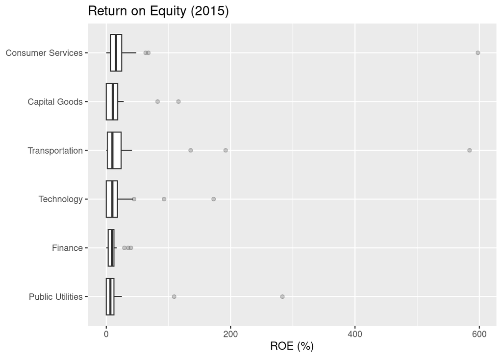

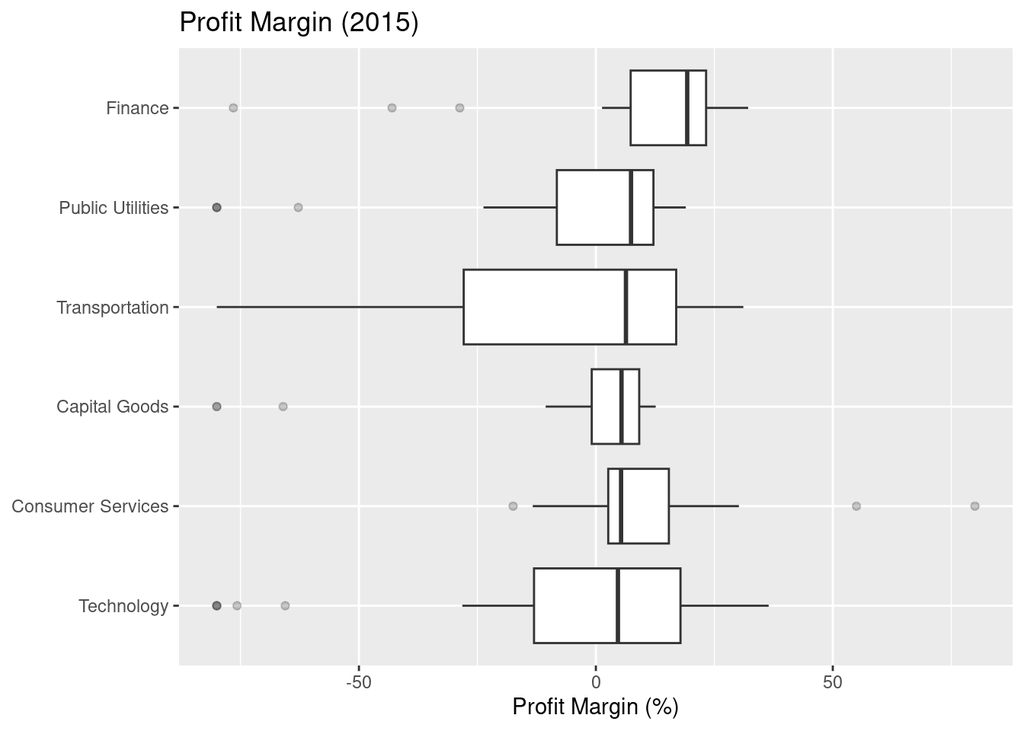

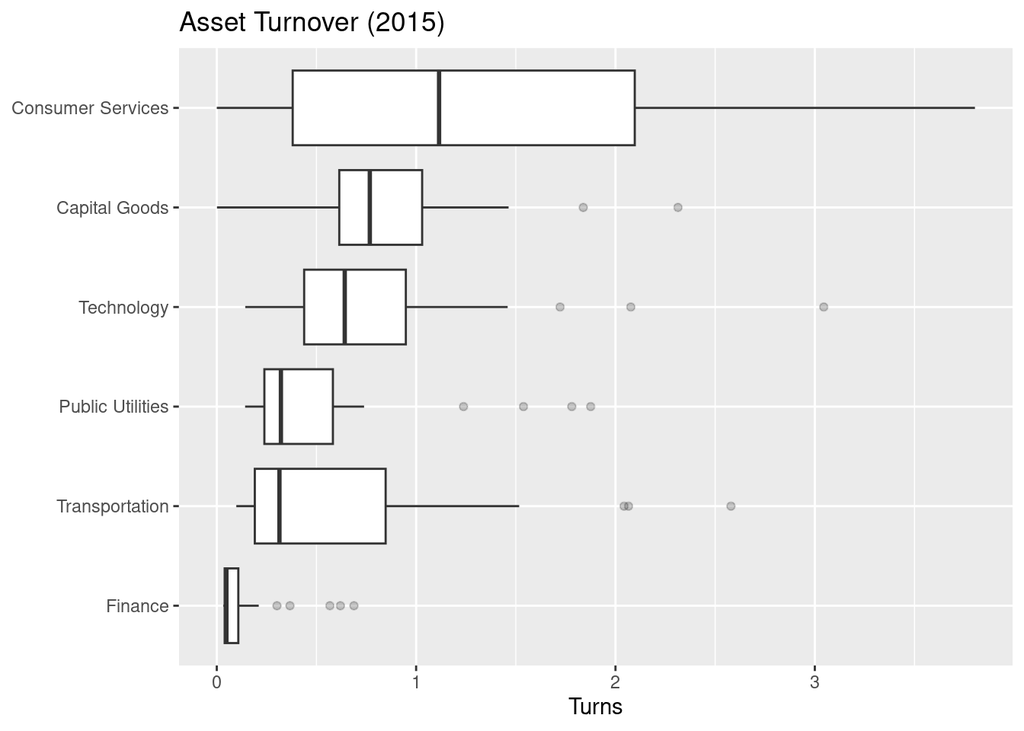

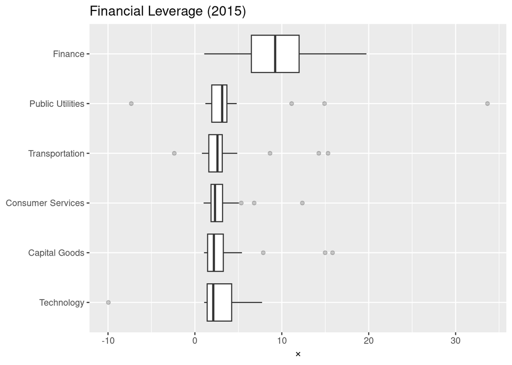

```r
# Use only cleaned variables for FY 2015
du2015 <- duPont %>%
  filter(Year == 2015) %>%
  # ensure Industry is a simple factor we control
  mutate(Industry = as.factor(as.character(Industry)))

# helper: compute industry order (ascending median) as a *character* vector
median_order_chr <- function(df, var) {
  df %>%
    group_by(Industry) %>%
    summarise(med = median({{ var }}, na.rm = TRUE), .groups = "drop") %>%
    arrange(med) %>%
    mutate(Industry = as.character(Industry)) %>%
    pull(Industry)
}

# generic boxplot maker
plot_box_by_industry <- function(df, var, title, ylab) {
  ord <- median_order_chr(df, {{ var }})
  ggplot(
    df,
    aes(
      x = forcats::fct_relevel(as.factor(as.character(Industry)), ord),
      y = {{ var }}
    )
  ) +
    geom_boxplot(outlier.alpha = 0.25) +
    coord_flip() +
    labs(title = title, x = NULL, y = ylab)
}

# build plots
p_roe <- plot_box_by_industry(du2015, ROE_clean,               "Return on Equity (2015)",       "ROE (%)")
p_pm  <- plot_box_by_industry(du2015, ProfitMargin_clean,      "Profit Margin (2015)",          "Profit Margin (%)")
p_at  <- plot_box_by_industry(du2015, AssetTurnover_clean,     "Asset Turnover (2015)",         "Turns")
p_fl  <- plot_box_by_industry(du2015, FinancialLeverage_clean, "Financial Leverage (2015)",     "×")

print(p_roe); print(p_pm); print(p_at); print(p_fl)
```

**Question 01, Student**

```r
# ---- GT summary: highest & lowest industries by median (2015) ----
median_rank_tbl <- function(df, var, label) {
  by_ind <- df %>%
    group_by(Industry) %>%
    summarise(median_value = median({{ var }}, na.rm = TRUE), .groups = "drop") %>%
    arrange(desc(median_value))

  tibble::tibble(
    Metric          = label,
    HighestIndustry = as.character(by_ind$Industry[1]),
    HighestMedian   = by_ind$median_value[1],
    LowestIndustry  = as.character(by_ind$Industry[nrow(by_ind)]),
    LowestMedian    = by_ind$median_value[nrow(by_ind)]
  )
}

summary_gt <- dplyr::bind_rows(
  median_rank_tbl(du2015, ROE_clean,               "ROE (%)"),
  median_rank_tbl(du2015, ProfitMargin_clean,      "Profit Margin (%)"),
  median_rank_tbl(du2015, AssetTurnover_clean,     "Asset Turnover (Turns)"),
  median_rank_tbl(du2015, FinancialLeverage_clean, "Financial Leverage (×)")
) %>%
  gt() %>%
  fmt_number(columns = c(HighestMedian, LowestMedian), decimals = 2) %>%
  tab_header(
    title = "Industry Performance (Median) — Fiscal Year 2015",
    subtitle = "Highest and Lowest Industries by Metric (using _clean variables)"
  ) %>%
  cols_label(
    Metric = "Metric",
    HighestIndustry = "Highest Industry",
    HighestMedian = "Highest (Median)",
    LowestIndustry = "Lowest Industry",
    LowestMedian = "Lowest (Median)"
  )

summary_gt
```

Industry Performance (Median) — Fiscal Year 2015

Highest and Lowest Industries by Metric (using _clean variables)

| Metric | Highest Industry | Highest (Median) | Lowest Industry | Lowest (Median) |
| --- | --- | --- | --- | --- |
| ROE (%) | Consumer Services | 15.56 | Public Utilities | 6.62 |
| Profit Margin (%) | Finance | 19.28 | Technology | 4.66 |
| Asset Turnover (Turns) | Consumer Services | 1.12 | Finance | 0.05 |
| Financial Leverage (×) | Finance | 9.23 | Technology | 2.11 |

**Analysis follow up:** Looking back at your answers in part II, were these results in line with your industry expectations?

**STUDENT RESPONSE REQUIRED**  
Yes—mostly in line with expectations, with one mild surprise: Finance: Highest profit margin and financial leverage, and very low asset turnover—exactly what we’d expect for banks/insurers (capital-heavy, leverage-driven returns, low “turns”). Consumer Services: Highest asset turnover and top ROE median—also expected; these are typically volume businesses with lighter asset bases and faster revenue cycling. Public Utilities: Lowest ROE—fits the regulated, capital-intensive model with capped returns despite steady margins. Technology: Lowest profit margin (median) was the only surprise; many marquee tech firms run high margins, but across the Dow cohort the combination of heavy R&D, pricing pressure in hardware, and a few negative-margin observations likely pulled the median down. Net: finance = high PM & leverage / low AT; services = high AT & ROE; utilities = low ROE; tech’s low PM median is plausible once you account for dispersion and outliers being controlled by the median.

2. Which industry has seen the greatest improvement in ROE from 2013 to 2015? Consider both the mean and median trends from 2013 to 2015. Create a chart to show the ROE for each industry over time.

**Question 02, Student**

```r
# Answer this sections question in well formed code.
#################################################################
# Student R code answer below
#################################################################

library(dplyr)
library(tidyr)
library(ggplot2)
library(forcats)
library(gt)
library(scales)

# Use only the _clean variables per instructions
du_1315 <- duPont %>%
  filter(Year %in% c(2013, 2014, 2015)) %>%
  group_by(Industry, Year) %>%
  summarise(
    ROE_mean   = mean(ROE_clean, na.rm = TRUE),
    ROE_median = median(ROE_clean, na.rm = TRUE),
    n          = dplyr::n(),
    .groups = "drop"
  )

# Compute improvement 2013 -> 2015
improvement <- du_1315 %>%
  filter(Year %in% c(2013, 2015)) %>%
  pivot_wider(
    names_from  = Year,
    values_from = c(ROE_mean, ROE_median),
    names_sep   = "_"
  ) %>%
  mutate(
    delta_mean   = ROE_mean_2015   - ROE_mean_2013,
    delta_median = ROE_median_2015 - ROE_median_2013
  ) %>%
  arrange(desc(delta_median), desc(delta_mean))

# Keep a neat summary table for the write-up, formatted with gt()
improve_tbl <- improvement %>%
  select(
    Industry,
    `Median 2013` = ROE_median_2013,
    `Median 2015` = ROE_median_2015,
    `Δ Median (pp)` = delta_median,
    `Mean 2013`  = ROE_mean_2013,
    `Mean 2015`  = ROE_mean_2015,
    `Δ Mean (pp)`  = delta_mean
  ) %>%
  mutate(
    across(everything(), ~ .x),
    across(where(is.numeric), ~ round(.x, 2))
  ) %>%
  arrange(desc(`Δ Median (pp)`)) %>%
  gt() %>%
  tab_header(
    title = md("**Industry ROE Improvement (2013 → 2015)**"),
    subtitle = "Changes shown in percentage points (pp) using _clean variables"
  ) %>%
  fmt_number(
    columns = where(is.numeric),
    decimals = 2
  ) %>%
  cols_align(everything(), align = "center")

improve_tbl
```

**Industry ROE Improvement (2013 → 2015)**

Changes shown in percentage points (pp) using _clean variables

| Industry | Median 2013 | Median 2015 | Δ Median (pp) | Mean 2013 | Mean 2015 | Δ Mean (pp) |
| --- | --- | --- | --- | --- | --- | --- |
| Consumer Services | 13.41 | 15.56 | 2.15 | 15.63 | 40.34 | 24.71 |
| Technology | 12.69 | 9.81 | −2.89 | 32.14 | 19.19 | −12.95 |
| Capital Goods | 9.60 | NA | NA | 63.39 | NA | NA |
| Capital Goods | NA | 10.48 | NA | NA | 16.04 | NA |
| Finance | 6.21 | NA | NA | 8.01 | NA | NA |
| Finance | NA | 9.28 | NA | NA | 10.67 | NA |
| Public Utilities | 7.15 | NA | NA | 8.51 | NA | NA |
| Public Utilities | NA | 6.62 | NA | NA | 20.32 | NA |
| Transportation | 9.32 | NA | NA | 52.29 | NA | NA |
| Transportation | NA | 9.86 | NA | NA | 42.68 | NA |

**Question 02, Student**

```r
# Identify the "winners" for your follow-up text
top_median <- improvement %>% slice_max(delta_median, n = 1)
top_mean   <- improvement %>% slice_max(delta_mean,   n = 1)

print(top_median)
```

```
# A tibble: 1 × 8
  Industry         n ROE_mean_2013 ROE_mean_2015 ROE_median_2013 ROE_median_2015
  <fct>        <int>         <dbl>         <dbl>           <dbl>           <dbl>
1 Consumer Se…    28          15.6          40.3            13.4            15.6
# ℹ 2 more variables: delta_mean <dbl>, delta_median <dbl>
```

**Question 02, Student**

```r
print(top_mean)
```

```
# A tibble: 1 × 8
  Industry         n ROE_mean_2013 ROE_mean_2015 ROE_median_2013 ROE_median_2015
  <fct>        <int>         <dbl>         <dbl>           <dbl>           <dbl>
1 Consumer Se…    28          15.6          40.3            13.4            15.6
# ℹ 2 more variables: delta_mean <dbl>, delta_median <dbl>
```

**Question 02, Student**

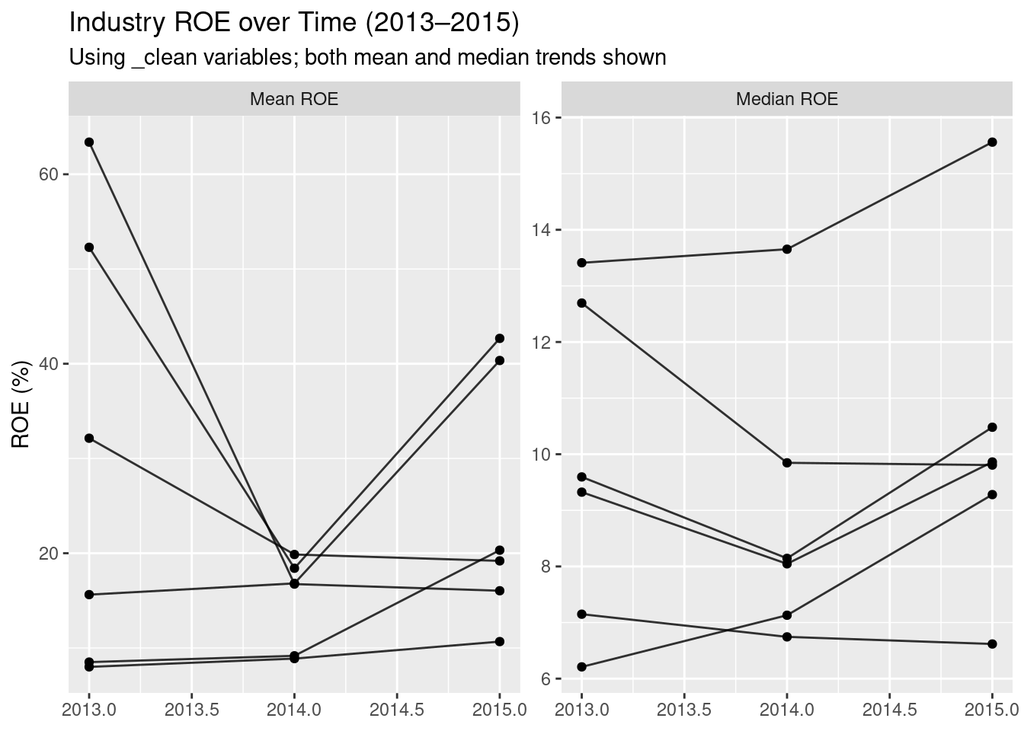

```r
# Line chart over time for each industry (mean & median facets)
du_1315_long <- du_1315 %>%
  pivot_longer(
    cols = c(ROE_mean, ROE_median),
    names_to = "metric",
    values_to = "ROE_value"
  ) %>%
  mutate(
    metric = recode(metric,
                    ROE_mean   = "Mean ROE",
                    ROE_median = "Median ROE")
  )

ggplot(du_1315_long, aes(x = Year, y = ROE_value, group = Industry, label = Industry)) +
  geom_line(alpha = 0.8) +
  geom_point(size = 1.5) +
  facet_wrap(~ metric, scales = "free_y") +
  labs(
    title = "Industry ROE over Time (2013–2015)",
    subtitle = "Using _clean variables; both mean and median trends shown",
    x = NULL,
    y = "ROE (%)"
  )
```

**Analysis follow up:** How many industries have an improvment between 2013 & 2015.

**Questions about individual companies**

3. What companies have the best ROE within each industry for 2015? Sort the data so you can see the companies listed from highest to lowest ROE. Make a sorted horizontal barchart to show your answer.

**Question 03, Student**

```r
# Answer this sections question in well formed code.
#################################################################
# Student R code answer below
#################################################################

library(dplyr)
library(ggplot2)
library(gt)
library(scales)

# 1) Best ROE by industry (2015) using _clean variables
best_by_ind_2015 <- duPont %>%
  filter(Year == 2015, !is.na(ROE_clean)) %>%
  group_by(Industry) %>%
  slice_max(ROE_clean, n = 1, with_ties = FALSE) %>%
  ungroup() %>%
  arrange(desc(ROE_clean)) %>%
  mutate(Company = paste0(Name, " (", Ticker, ")"))

# 2) GT table (sorted high → low)
best_by_ind_2015 %>%
  select(Industry, Company, ROE_clean) %>%
  gt(rowname_col = "Industry") %>%
  fmt_number(columns = ROE_clean, decimals = 2, suffixing = FALSE) %>%
  cols_label(
    Company  = "Top Company (2015)",
    ROE_clean = "ROE (%)"
  ) %>%
  tab_header(
    title = md("**Best ROE by Industry (2015)**"),
    subtitle = md("Using `_clean` variables")
  )
```

**Best ROE by Industry (2015)**

Using `_clean` variables

|  | Top Company (2015) | ROE (%) |
| --- | --- | --- |
| Consumer Services | Caesars Entertainment Corporation (CZR) | 597.77 |
| Transportation | Paragon Shipping Inc. (PRGN) | 584.29 |
| Public Utilities | BT Group PLC (BT) | 283.33 |
| Technology | Barracuda Networks Inc. (CUDA) | 172.63 |
| Capital Goods | Lockheed Martin Corp. (LMT) | 116.13 |
| Finance | Armada Hoffler Properties Inc. (AHH) | 39.60 |

**Question 03, Student**

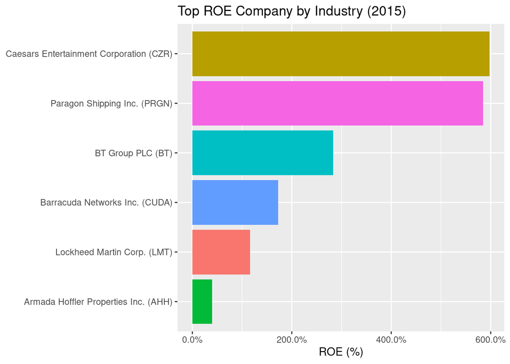

```r
# 3) Horizontal bar chart (sorted)
ggplot(best_by_ind_2015,
       aes(x = reorder(Company, ROE_clean), y = ROE_clean, fill = Industry)) +
  geom_col() +
  coord_flip() +
  labs(
    title = "Top ROE Company by Industry (2015)",
    x = NULL,
    y = "ROE (%)"
  ) +
  guides(fill = "none") +
  scale_y_continuous(labels = number_format(accuracy = 0.1, suffix = "%"))
```

**Analysis follow up:** What is the company has the best ROE for 2015 within `Public Utilities`

**STUDENT RESPONSE REQUIRED**  
The company with the best ROE in the Public Utilities industry for 2015 is **BT Group PLC (Ticker: BT)**. It achieved an ROE of approximately **283.33%** using the cleaned ROE values.

4. Companies that have negative profit margins but are increasing their asset turnover ratio are “accelerating into a brick wall” (i.e., they are getting better at losing money). What companies in 2015 are the worst in that they have a negative profit margin and the highest asset turnover ratio? Create a chart to show your answer.

**Question 04, Student**

```r
# Answer this sections question in well formed code.
#################################################################
# Student R code answer below
#################################################################

library(dplyr)
library(ggplot2)
library(forcats)
library(gt)
library(scales)

# 1) Filter the 2015 "brick wall" set: negative PM & highest AT
brick_2015 <- duPont %>%
  filter(Year == 2015) %>%
  filter(!is.na(ProfitMargin_clean), !is.na(AssetTurnover_clean)) %>%
  filter(ProfitMargin_clean < 0) %>%
  arrange(desc(AssetTurnover_clean)) %>%
  mutate(
    Company = paste0(Name, " (", Ticker, ")")
  )

# 2) Show the top 10 offenders as a gt table
brick_top10_tbl <- brick_2015 %>%
  slice_head(n = 10) %>%
  select(Industry, Company,
         `Profit Margin (%)` = ProfitMargin_clean,
         `Asset Turnover (Turns)` = AssetTurnover_clean,
         `ROE (%)` = ROE_clean)

brick_top10_tbl %>%
  gt() %>%
  tab_header(
    title = md("**Negative Profit Margin + Highest Asset Turnover (2015)**"),
    subtitle = md("Top 10 companies using `_clean` variables")
  ) %>%
  fmt_number(
    columns = c(`Profit Margin (%)`, `ROE (%)`),
    decimals = 2
  ) %>%
  fmt_number(
    columns = `Asset Turnover (Turns)`,
    decimals = 2
  ) %>%
  cols_align(
    align = "right",
    columns = c(`Profit Margin (%)`, `Asset Turnover (Turns)`, `ROE (%)`)
  )
```

**Negative Profit Margin + Highest Asset Turnover (2015)**

Top 10 companies using `_clean` variables

| Industry | Company | Profit Margin (%) | Asset Turnover (Turns) | ROE (%) |
| --- | --- | --- | --- | --- |
| Technology | Staffing 360 Solutions Inc. (STAF) | −13.98 | 3.04 | 0.00 |
| Consumer Services | Cosi Inc. (COSI) | −17.46 | 2.18 | 0.00 |
| Transportation | DryShips Inc. (DRYS) | −80.00 | 2.04 | NA |
| Public Utilities | Active Power Inc (ACPW) | −11.32 | 1.88 | 0.00 |
| Capital Goods | Tel-Instrument Electronics Corp. (TIK) | −1.54 | 1.84 | 0.00 |
| Public Utilities | Zhone Technologies Inc. (ZHNE) | −1.98 | 1.78 | 0.00 |
| Technology | Groupon Inc. (GRPN) | −4.31 | 1.72 | 0.00 |
| Technology | Lantronix Inc. (LTRX) | −6.53 | 1.46 | 0.00 |
| Public Utilities | Glowpoint Inc. (GLOW) | −8.24 | 1.24 | 0.00 |
| Capital Goods | Advanced Drainage Systems Inc. (WMS) | −0.20 | 1.20 | 0.00 |

**Question 04, Student**

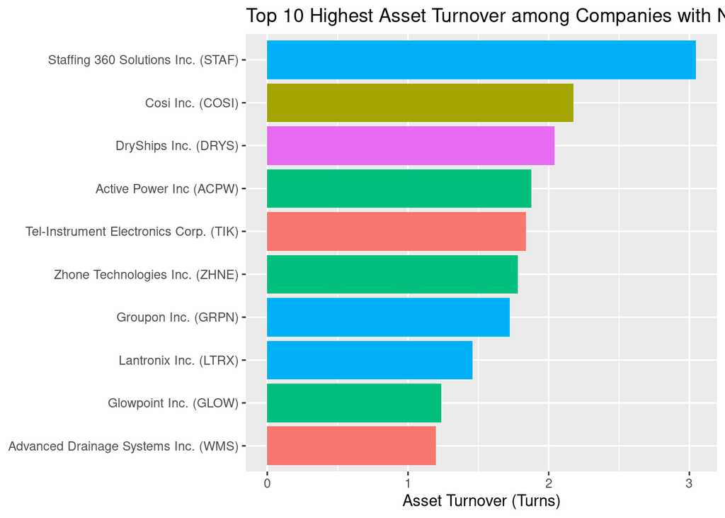

```r
# 3) Plot: ranked horizontal bar chart for top 10 by Asset Turnover
brick_2015 %>%
  slice_head(n = 10) %>%
  ggplot(aes(x = fct_reorder(Company, `AssetTurnover_clean`),
             y = `AssetTurnover_clean`, fill = Industry)) +
  geom_col() +
  coord_flip() +
  labs(
    title = "Top 10 Highest Asset Turnover among Companies with Negative Profit Margin (2015)",
    x = NULL, y = "Asset Turnover (Turns)"
  ) +
  guides(fill = "none")
```

**Question 04, Student**

```r
# 4) Helper object for your follow-up text:
top_transportation_concern <- brick_2015 %>%
  filter(Industry == "Transportation") %>%
  slice_head(n = 1) %>%
  select(Company,
         `Profit Margin (%)` = ProfitMargin_clean,
         `Asset Turnover (Turns)` = AssetTurnover_clean)

top_transportation_concern %>%
  gt() %>%
  tab_header(title = md("**Top Transportation Concern (2015)**")) %>%
  fmt_number(columns = `Profit Margin (%)`, decimals = 2) %>%
  fmt_number(columns = `Asset Turnover (Turns)`, decimals = 2)
```

**Top Transportation Concern (2015)**

| Company | Profit Margin (%) | Asset Turnover (Turns) |
| --- | --- | --- |
| DryShips Inc. (DRYS) | −80.00 | 2.04 |

**Analysis follow up:** What is the top ranked company within `Transportation` that has this concern?

**STUDENT RESPONSE REQUIRED**  
DryShips Inc. (DRYS) — with a profit margin around −80.0% and asset turnover about 2.04 turns — is the top-ranked Transportation company exhibiting this concern in 2015.

5. Select one of your questions your asked from Part II and answer it. It should be not be a significant overlap to the above questions. Please copy the question below and answer in the code chunk. **1. What are the combined total assets (in millions) of all companies for each years? As well as, the count of the number of companies for each year.**

**Question 05, Student**

```r
# Answer this sections question in well formed code.
#################################################################
# Student R code answer below
#################################################################



q1_assets_by_year <- duPont %>%
  group_by(Year) %>%
  summarize(
    total_assets_millions = sum(TotalAssets, na.rm = TRUE),
    company_count         = n_distinct(Ticker),
    .groups = "drop"
  ) %>%
  arrange(Year)

q1_assets_by_year %>%
  gt() %>%
  tab_header(
    title = "Total Assets (Millions) and Company Count by Year"
  ) %>%
  fmt_number(
    columns = c(total_assets_millions),
    decimals = 2
  )
```

Total Assets (Millions) and Company Count by Year

| Year | total_assets_millions | company_count |
| --- | --- | --- |
| 2013 | 19,431,720,847,200.00 | 172 |
| 2014 | 19,807,526,200,000.00 | 173 |
| 2015 | 19,589,325,400,000.00 | 171 |

**Analysis follow up:** Student selected…

**STUDENT RESPONSE REQUIRED**  
The results show that the total combined assets remained relatively stable across the three years, with a slight increase from 2013 to 2014 and a small decline in 2015. The highest total assets occurred in **2014** at approximately **$19.81 trillion**, while **2013** had the lowest total at about **$19.43 trillion**. The number of companies included in the dataset also remained consistent, ranging narrowly from **171 to 173 companies** each year. These results suggest that the overall market size in terms of asset base did not significantly change across the three years, although there were small shifts in participation and total reported assets.

## Session Info

```r
date()
```

```
[1] "Sun Nov  9 17:38:34 2025"
```

```r
Sys.getenv()
```

[output not shown]

[output cut: 79 more lines]

[output not shown]